# Clean Audio Metadata

Kendra Wyant

2021-03-16

### Notes

Purpose: This script gets metadata info regarding daily check in, such as number of days with audio, file names, and duration of audio clip.

**Can add audio transcripts to this script at a later date**

FIX: This script takes a long time to run - need to use future_map or foreach loops to speed it up but I have not figured out how to do this yet.

Inputs:  
* raw audio files

### Setup

Paths

```r
path_raw <- "/Volumes/private/StudyData/RISK/raw_data"
path_out <- "/Volumes/private/StudyData/RISK/analysis/shared/data"
```

Packages and Source

```r
library(tidyverse)
library(kableExtra)
library(lubridate)
library(av)
```

### Read in audio files

#### Function

```r
read_audio <- function(subid) {
    audio_log <- tibble(subid = character(),
                   message = character())
    audio_files <- list.files(file.path(path_raw, subid, "Audio"))
    if(length(audio_files) > 0) {
      for(file in audio_files) {
        path <- file.path(path_raw, subid, "Audio", file)
        extension <- str_extract(path, "[^.]*$")

        # filter out non-audio files
        if(extension != "db" & extension != "lnk") {

          log <- tibble(subid = subid,
                 audio_file_name = file,
                 created = file.info(path)$ctime,
                 modified = file.info(path)$mtime,

                 # estimated duration of audio clip from bitrate
                 duration = av_media_info(path)$duration) %>%

                 # extract date from file name
                 mutate(date = str_trunc(audio_file_name, 13, "right", ellipsis = ""),
                 date = str_trunc(date, 9, "left", ellipsis = ""),
                 date = str_replace(date, "_", ""),
                 date = ymd(date))

          audio_log <- audio_log %>%
            full_join(log)
        }
      }
      return(audio_log)
      } else if(length(audio_files) == 0){
        audio_log <- audio_log %>% add_row(subid = subid, message = "No audio files found")
        return(audio_log)
    }
}
```

#### Get subids

```r
subids <- list.dirs(path_raw, recursive = FALSE, full.names = FALSE) %>%
  keep(~ str_detect(.x, "([0-2][0-9][0-9])")) %>%
  enframe(name = NULL, value = "subid")
```

#### Read in all audio files

```r
all_audio <- tibble(subid = character())
all_audio <- map_df(subids$subid, ~read_audio(.)) %>%
  glimpse()
```

```
## Rows: 7,599
## Columns: 7
## $ subid           <chr> "001", "001", "001", "001", "001", "001", "001", "001…
## $ message         <chr> NA, NA, NA, NA, NA, NA, NA, NA, NA, NA, NA, NA, NA, N…
## $ audio_file_name <chr> "001_2017_0302_1000.m4a", "001_2017_0304_0649.m4a", "…
## $ created         <dttm> 2017-03-02 10:01:29, 2017-03-06 09:36:20, 2017-03-06…
## $ modified        <dttm> 2017-03-02 10:01:29, 2017-03-06 09:36:20, 2017-03-06…
## $ duration        <dbl> 25.2, 19.5, 22.7, 26.5, 42.7, 35.5, 53.2, 38.7, 32.7,…
## $ date            <date> 2017-03-02, 2017-03-04, 2017-03-05, 2017-03-06, 2017…
```

### EDA

```r
table(all_audio$message)
```

```
##
## No audio files found
##                   54
```

```r
audio <- all_audio %>%
  filter(is.na(message)) %>%
  select(subid, date, duration, everything(), -message) %>%
  glimpse()
```

```
## Rows: 7,545
## Columns: 6
## $ subid           <chr> "001", "001", "001", "001", "001", "001", "001", "001…
## $ date            <date> 2017-03-02, 2017-03-04, 2017-03-05, 2017-03-06, 2017…
## $ duration        <dbl> 25.2, 19.5, 22.7, 26.5, 42.7, 35.5, 53.2, 38.7, 32.7,…
## $ audio_file_name <chr> "001_2017_0302_1000.m4a", "001_2017_0304_0649.m4a", "…
## $ created         <dttm> 2017-03-02 10:01:29, 2017-03-06 09:36:20, 2017-03-06…
## $ modified        <dttm> 2017-03-02 10:01:29, 2017-03-06 09:36:20, 2017-03-06…
```

```r
no_audio <- all_audio %>%
  filter(message == "No audio files found") %>%
  select(subid, message) %>%
  glimpse()
```

```
## Rows: 54
## Columns: 2
## $ subid   <chr> "004", "012", "013", "014", "022", "035", "036", "045", "046"…
## $ message <chr> "No audio files found", "No audio files found", "No audio fil…
```

7545 sleep observations from 162 subids.  
54 subids have no audio files.  
*Subids with no audio were mnaually confirmed by checking raw data folders*

Audio data ranges from 2017-03-02 to 2019-12-04

#### audio files per subid

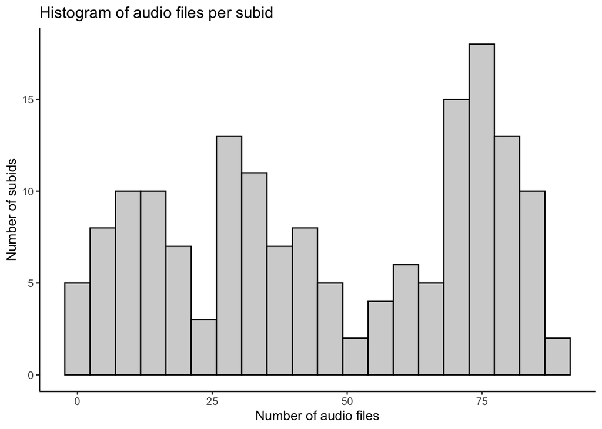

```r
audio %>%
  count(subid) %>%
  ggplot(aes(x = n)) +
  geom_histogram(color = "black", fill = "light grey", bins = 20) +
  theme_classic() +
  labs(title = "Histogram of audio files per subid",
       x = "Number of audio files",
       y = "Number of subids")
```

more than 90 days worth of audio files

```r
audio %>%
  count(subid) %>%
  filter(n > 90)
```

```
## # A tibble: 0 x 2
## # … with 2 variables: subid <chr>, n <int>
```

#### check for duplicate dates

```r
audio %>%
  count(subid, date) %>%
  filter(n > 1) %>%
  arrange(desc(n))
```

```
## # A tibble: 136 x 3
##    subid date           n
##    <chr> <date>     <int>
##  1 128   2018-11-24     3
##  2 175   2019-04-03     3
##  3 255   2019-10-24     3
##  4 264   2019-10-26     3
##  5 264   2019-10-27     3
##  6 270   2019-09-22     3
##  7 007   2017-07-02     2
##  8 011   2017-08-23     2
##  9 011   2017-09-13     2
## 10 011   2017-09-18     2
## # … with 126 more rows
```

```r
audio %>%
  filter(subid == 128) %>%
  select(subid, date, duration) %>%
  print(n = Inf)
```

```
## # A tibble: 85 x 3
##    subid date       duration
##    <chr> <date>        <dbl>
##  1 128   2018-09-09    66.0
##  2 128   2018-09-10    52.2
##  3 128   2018-09-11    27.6
##  4 128   2018-09-12    45.3
##  5 128   2018-09-13    51.7
##  6 128   2018-09-14   124.
##  7 128   2018-09-15    20.3
##  8 128   2018-09-16    33.2
##  9 128   2018-09-17    32.5
## 10 128   2018-09-18    45.8
## 11 128   2018-09-19    30.0
## 12 128   2018-09-20    80.7
```

[output cut: 73 more lines]

FIX: Not clear why there is duplicate entries on a single date. Possibly they thought the audio was not sending. Will investigate more at a later date.

#### Duration

Audio files range from 1.08 to 425.52 seconds in duration.

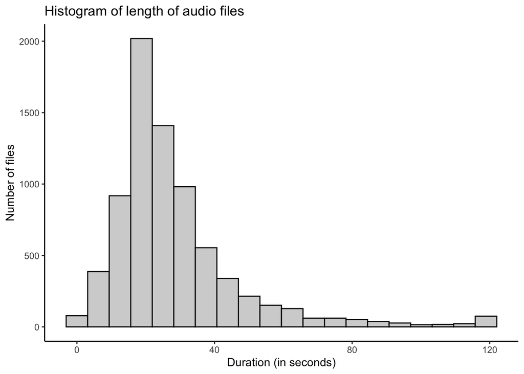

```r
audio %>%
  mutate(duration = case_when(duration > 120 ~ 120,
                              TRUE ~ duration)) %>%
  ggplot(aes(x = duration)) +
  geom_histogram(color = "black", fill = "light grey", bins = 20) +
  theme_classic() +
  labs(title = "Histogram of length of audio files",
       x = "Duration (in seconds)",
       y = "Number of files")
```

files less than 5 seconds long

```r
short_audio <- audio %>%
  filter(duration < 5) %>%
  select(subid, date, duration)
```

There are 165 short audio files (less than 5 seconds long), but there is a clear pattern among subids.  
22 subids make up all the short audio clips.

```r
print(short_audio, n = Inf)
```

```
## # A tibble: 165 x 3
##     subid date       duration
##     <chr> <date>        <dbl>
##   1 023   2017-11-10     4
##   2 023   2017-11-11     2.6
##   3 023   2017-11-12     3.9
##   4 029   2017-11-08     3.8
##   5 029   2017-11-09     3.3
##   6 029   2017-11-18     4.5
##   7 029   2017-11-20     4.3
##   8 029   2017-11-24     2.6
##   9 029   2017-11-25     2.7
##  10 029   2017-12-03     3.6
##  11 029   2017-12-05     3.2
##  12 029   2017-12-06     1.8
```

[output cut: 153 more lines]

### Write csv

```r
write_csv(audio, file.path(path_out, "audio.csv")) %>%
  glimpse()
```

```
## Rows: 7,545
## Columns: 6
## $ subid           <chr> "001", "001", "001", "001", "001", "001", "001", "001…
## $ date            <date> 2017-03-02, 2017-03-04, 2017-03-05, 2017-03-06, 2017…
## $ duration        <dbl> 25.2, 19.5, 22.7, 26.5, 42.7, 35.5, 53.2, 38.7, 32.7,…
## $ audio_file_name <chr> "001_2017_0302_1000.m4a", "001_2017_0304_0649.m4a", "…
## $ created         <dttm> 2017-03-02 10:01:29, 2017-03-06 09:36:20, 2017-03-06…
## $ modified        <dttm> 2017-03-02 10:01:29, 2017-03-06 09:36:20, 2017-03-06…
```